# Composition Analysis of the English Short Title Catalogue dated 2020-09

# Overall summary

486,261 records and 22,499,946 attribute values in total. Constituent files:

- data/estc/estc.parquet (78.2MB)

## Temporal overview

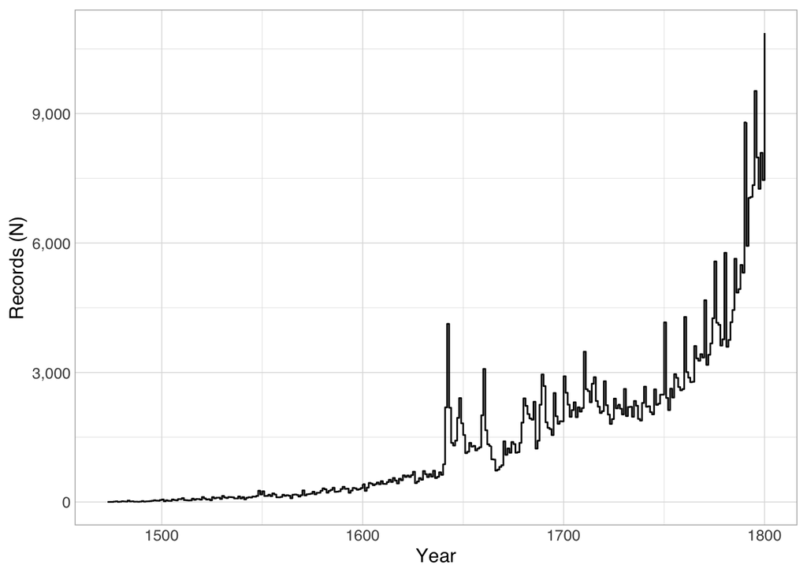

301 records do not have easily parseable dates between the years 1400 and 1800.

## Language overview

| [] | Records (N) | Proportion (%) |
| --- | --- | --- |
| eng (English) | 456156 | 0.938088804160728 |
| lat (Latin) | 16271 | 0.0334614538282939 |
| fre (French) | 7922 | 0.0162916622965856 |
| ger (German) | 1687 | 0.00346933025679625 |
| wel (Welsh) | 961 | 0.00197630490621292 |
| roa (Romance languages) | 773 | 0.00158968126170925 |
| ita (Italian) | 604 | 0.00124213128340541 |
| grc (Greek, Ancient (to 1453)) | 525 | 0.00107966709236398 |
| mul (Multiple languages) | 272 | 0.000559370379281908 |
| dut (Dutch; Flemish) | 227 | 0.00046682748565071 |

[output cut: 44 more lines]

# Field code usage overview

In total, 82 distinct fields are used.

Legend for the table below:

- `records`: how many records have at least one of this field
- `r_p`: the above as a percentage of all records
- `n`: the total number of appearances of this field
- `vals_per_rec`: calculated from the above, the mean number of appearances of this field per record
- `recs_with_mult_vals`: the number of records that have more than one repetition of this field

| field_code | field_description | records | r_p | n | vals_per_rec | recs_with_mult_vals |
| --- | --- | --- | --- | --- | --- | --- |
| <a name="001" href="https://www.loc.gov/marc/bibliographic/bd001.html">001</a> | Control Number | 486261 | 1 | 486261 | 1 | 0 |
| <a name="003" href="https://www.loc.gov/marc/bibliographic/bd003.html">003</a> | Control Number Identifier | 486261 | 1 | 486261 | 1 | 0 |
| <a name="005" href="https://www.loc.gov/marc/bibliographic/bd005.html">005</a> | Date and Time of Latest Transaction | 486261 | 1 | 486261 | 1 | 0 |
| <a name="008" href="https://www.loc.gov/marc/bibliographic/bd008.html">008</a> | General Information | 486261 | 1 | 486261 | 1 | 0 |
| <a name="035" href="https://www.loc.gov/marc/bibliographic/bd035.html">035</a> | System Control Number | 486241 | 0.999958869825053 | 501409 | 1.0311944077114 | 12677 |
| <a name="040" href="https://www.loc.gov/marc/bibliographic/bd040.html">040</a> | Cataloging Source | 486235 | 0.999946530772569 | 1955799 | 4.02233282260635 | 486204 |
| <a name="041" href="https://www.loc.gov/marc/bibliographic/bd041.html">041</a> | Language Code | 181 | 0.000372228083272152 | 494 | 2.7292817679558 | 181 |
| <a name="042" href="https://www.loc.gov/marc/bibliographic/bd042.html">042</a> | Authentication Code | 11 | 2.26215962209595e-05 | 12 | 1.09090909090909 | 1 |
| <a name="043" href="https://www.loc.gov/marc/bibliographic/bd043.html">043</a> | Geographic Area Code | 2653 | 0.00545591770674597 | 3276 | 1.23482849604222 | 545 |
| <a name="046" href="https://www.loc.gov/marc/bibliographic/bd046.html">046</a> | Special Coded Dates | 123 | 0.000252950575925275 | 248 | 2.01626016260163 | 123 |

[output cut: 72 more lines]

# Field code usage overview by subfield

In total, 513 distinct field+subfield combinations are used.

Legend for the table below:

- `records`: how many records have at least one of this field+subfield
- `r_p`: the above as a percentage of all records
- `dist_vals`: the number of different values appearing in this field+subfield
- `e_vals`: at most seven random sample values of this field+subfield
- `n`: the total number of appearances of this field+subfield
- `vals_per_rec`: calculated from the above, the mean number of appearances of this field+subfield per record
- `recs_with_mult_vals`: the number of records that have more than one repetition of this field+subfield

| subfield_code | subfield_description | records | r_p | dist_vals | e_vals | n | vals_per_rec | recs_with_mult_vals |
| --- | --- | --- | --- | --- | --- | --- | --- | --- |
| [001: Control Number](https://www.loc.gov/marc/bibliographic/bd001.html) |  |  |  |  |  |  |  |  |
| 001$ | NA | 486,261 | 100% | 486,261 | 006369738 (1)\|006156234 (1)\|006081584 (1)\|006056655 (1)\|006483002 (1)\|006099862 (1)\|006133637 (1) | 486,261 | 1 | 0 |
| [003: Control Number Identifier](https://www.loc.gov/marc/bibliographic/bd003.html) |  |  |  |  |  |  |  |  |
| 003$ | NA | 486,261 | 100% | 1 | Uk-ES (486261) | 486,261 | 1 | 0 |
| [005: Date and Time of Latest Transaction](https://www.loc.gov/marc/bibliographic/bd005.html) |  |  |  |  |  |  |  |  |
| 005$ | NA | 486,261 | 100% | 109,309 | 20171023124730.0 (1)\|20090325181347.0 (1)\|20161202200446.0 (1)\|20081014145702.0 (1)\|20170322170456.0 (1)\|20110528170059.0 (1)\|20101104000825.0 (1) | 486,261 | 1 | 0 |
| [008: General Information](https://www.loc.gov/marc/bibliographic/bd008.html) |  |  |  |  |  |  |  |  |
| 008$ | NA | 486,261 | 100% | 287,910 | 960320d16891691enkwr n \|\|\| 0 \|a0eng c (1)\|950918s1637 enk a 000 0 eng c (2)\|820210s1767 enk\|\|\|\| \|00\| \|\|eng c (1)\|790201s1724 enk\|\|\|\| 00\|\|\|\|eng c (2)\|940920s1769 enk\|\|\|\| 00\… | 486,261 | 1 | 0 |
| [035: System Control Number](https://www.loc.gov/marc/bibliographic/bd035.html) |  |  |  |  |  |  |  |  |
| 035$9 | NA | 11 | 0% | 11 | 0114-76860 (1)\|0846-70160 (1)\|1260-07460 (1)\|0846-71260 (1)\|1750-61060 (1)\|0649-31360 (1)\|1240-50560 (1) | 11 | 1 | 0 |
| 035$a | System control number | 486,241 | 100% | 486,262 | (CU-RivES)N71818 (1)\|(CU-RivES)T21529 (1)\|(CU-RivES)W5971 (1)\|(CU-RivES)T198997 (1)\|(CU-RivES)R13634 (1)\|(CU-RivES)T210327 (1)\|(CU-RivES)T95693 (1) | 486,293 | 1 | 49 |
| 035$z | Cancelled/invalid system control number | 12,623 | 2.6% | 14,788 | (CU-RivES)N53934 (1)\|(CU-RivES)S109283 (1)\|(CU-RivES)T136537 (1)\|(CU-RivES)S1581 (1)\|(CU-RivES)S110549 (1)\|(CU-RivES)R41882 (1)\|(CU-RivES)T137710 (1) | 15,105 | 1.2 | 1,853 |
| [040: Cataloging Source](https://www.loc.gov/marc/bibliographic/bd040.html) |  |  |  |  |  |  |  |  |
| 040$3 | NA | 1 | 0% | 1 | dcrmb (1) | 1 | 1 | 0 |
| 040$D | NA | 3 | 0% | 2 | Uk-ES (2)\|CU-RivES (1) | 3 | 1 | 0 |
| 040$U | NA | 3 | 0% | 1 | k-ES (3) | 3 | 1 | 0 |
| 040$a | Original cataloging agency | 486,200 | 99.99% | 56 | CUD (1)\|Cu-RivES (25)\|CU-Riv (2)\|UK-ES (13)\|CCU-RivES (6)\|EAH (1)\|JHE (1) | 486,227 | 1 | 27 |
| 040$b | Language of cataloging | 721 | 0.15% | 4 | eng (363)\|Uk-ES (3)\|CU-RivES (354)\|dcrmb (1) | 721 | 1 | 0 |
| 040$c | Transcribing agency | 485,461 | 99.84% | 66 | PJU (1)\|CU-RivEs (2)\|UMI (14)\|CU-RivES LIN (2)\|CU-RivES e dcrb (1)\|EAH (1)\|CU-Riv0ES (1) | 485,491 | 1 | 30 |
| 040$d | Modifying agency | 438,707 | 90.22% | 106 | CCU-RivES (1)\|CStRLINCU-RivES (8)\|dcrb (545)\|Cu-RuvES (1)\|CuRivES (9)\|Uk - ES (1)\|CU-RivES N (1) | 822,926 | 1.88 | 279,186 |
| 040$e | Description conventions | 160,406 | 32.99% | 43 | drb (1)\|dcrb upd (1)\|dcms (1)\|dcr,b (1)\|dcrmb. (1)\|dccrmb (1)\|dcrb\ (1) | 160,425 | 1 | 19 |
| 040$s | NA | 1 | 0% | 1 | Uk-ES (1) | 1 | 1 | 0 |
| 040$v | NA | 1 | 0% | 1 | CU-RivES (1) | 1 | 1 | 0 |
| [041: Language Code](https://www.loc.gov/marc/bibliographic/bd041.html) |  |  |  |  |  |  |  |  |
| 041$Y | NA | 180 | 0.04% | 4 | a (1)\|0 (59)\|1 (116)\|n (4) | 180 | 1 | 0 |
| 041$Z | NA | 5 | 0% | 2 | g (4)\|t (1) | 5 | 1 | 0 |
| 041$a | Language code of text/sound track or separate title | 181 | 0.04% | 31 | latgreheb (1)\|englatgre (1)\|latgre (2)\|engfreita (1)\|lat (15)\|englat (6)\|gereng (9) | 197 | 1.09 | 15 |
| 041$d | Language code of sung or spoken text | 1 | 0% | 1 | ita (1) | 1 | 1 | 0 |
| 041$g | Language code of accompanying material other than librettos | 3 | 0% | 2 | ger (1)\|eng (2) | 3 | 1 | 0 |
| 041$h | Language code of original and/or intermediate translations of text | 105 | 0.02% | 16 | eng (26)\|heb (6)\|lat (13)\|grclat (1)\|ger (7)\|per (1)\|dut (7) | 108 | 1.03 | 3 |

[output cut: 565 more lines]